# Case Study: Miles Per Gallon (MPG) Prediction

MSBA7002: Business Statistics

Read:

- Chapter 6.1 and 2.2.1-2.2.2

Objectives:

1. Exploratory Data Analysis (EDA)
   - Checking Missing Value
   - Data Cleaning
2. LASSO (Least Absolute Shrinkage and Selection Operator)
   - Understand `glmnet()` & `cv.glmnet()`
   - How to use Lasso Output
3. K-Fold Cross Validation (Appendix III)
   - Cross-Validation Error
4. Ridge Regression
5. Elastic Net
   - Combination of Ridge Regression and LASSO
   - $\alpha=0$ gives us Ridge Regression, $\alpha= 1$ gives us LASSO

## Case Study: Miles Per Gallon (MPG) Prediction

- We will use `car04` data.
- The dataset contains characteristics of various makes and models of cars from the 2003 and 2004 model years.

**Goal of the study:**

- How to use regularization method to choose an optimal model?
- How to use Cross-Validation to choose tuning parameters?

## 1. Exploratory Data Analysis (EDA)

### Take a quick look at the data

```r
data.car0 <- read.csv("cars04.dat")
```

How many vehicles (observations) and variables are contained in the dataset?

```r
dim(data.car0)
```

```
## [1] 223  28
```

Variable names

```r
names(data.car0)
```

```
##  [1] "MPG.City"                        "Weight"
##  [3] "Horsepower"                      "Wheelbase"
##  [5] "Price"                           "Torque..foot.lbs.."
##  [7] "Displacement..cu.in.."           "Pounds.HP"
##  [9] "Cargo.Volume..EPA."              "Passenger.Volume..EPA."
## [11] "Fuel.Capacity"                   "Combined.Fuel.Economy"
## [13] "Cylinders"                       "Seating..Standard."
## [15] "Transmission.Speeds"             "Transmission..Automatic.Manual."
## [17] "Height"                          "Length"
## [19] "Width"                           "Track..Front."
## [21] "Track..Rear."                    "Curb.Weight.AT"
## [23] "Curb.Weight.MT"                  "MPG.Highway"
## [25] "Sales.Volume"                    "Model"
## [27] "Model.Year"                      "Type"
```

Let’s see if we have any missing values.

```r
sum(is.na(data.car0)) # many missing values!!!!
```

```
## [1] 521
```

We have 521 missing values. **Is there a way to know in which columns these missing values are?**

```r
sapply(data.car0, function(x) any(is.na(x)))
```

```
##                        MPG.City                          Weight
##                            TRUE                           FALSE
##                      Horsepower                       Wheelbase
##                           FALSE                            TRUE
##                           Price              Torque..foot.lbs..
##                            TRUE                            TRUE
##           Displacement..cu.in..                       Pounds.HP
##                            TRUE                           FALSE
##              Cargo.Volume..EPA.          Passenger.Volume..EPA.
##                            TRUE                            TRUE
##                   Fuel.Capacity           Combined.Fuel.Economy
##                            TRUE                            TRUE
##                       Cylinders              Seating..Standard.
##                            TRUE                            TRUE
##             Transmission.Speeds Transmission..Automatic.Manual.
##                           FALSE                           FALSE
##                          Height                          Length
##                            TRUE                            TRUE
##                           Width                   Track..Front.
##                            TRUE                            TRUE
##                    Track..Rear.                  Curb.Weight.AT
##                            TRUE                            TRUE
##                  Curb.Weight.MT                     MPG.Highway
##                            TRUE                            TRUE
##                    Sales.Volume                           Model
##                            TRUE                           FALSE
##                      Model.Year                            Type
##                            TRUE                           FALSE
```

```r
    # any(is.na(var)) is very useful, it returns T/F for each var!
#apply(data.car, 2, function(x) any(is.na(x)))  # apply function by columns: column-wise missing
#apply(data.car, 1, function(x) any(is.na(x)))  # apply function by rows: row-wise missing
```

```r
sapply(data.car0, function(x) sum(is.na(x)))
```

```
##                        MPG.City                          Weight
##                               2                               0
##                      Horsepower                       Wheelbase
##                               0                               1
##                           Price              Torque..foot.lbs..
##                               1                               1
##           Displacement..cu.in..                       Pounds.HP
##                               6                               0
##              Cargo.Volume..EPA.          Passenger.Volume..EPA.
##                             104                             104
##                   Fuel.Capacity           Combined.Fuel.Economy
##                               1                              30
##                       Cylinders              Seating..Standard.
##                               2                               1
##             Transmission.Speeds Transmission..Automatic.Manual.
##                               0                               0
##                          Height                          Length
##                               2                               1
##                           Width                   Track..Front.
##                               1                               1
##                    Track..Rear.                  Curb.Weight.AT
##                               1                              37
##                  Curb.Weight.MT                     MPG.Highway
##                             124                               2
##                    Sales.Volume                           Model
##                              98                               0
##                      Model.Year                            Type
##                               1                               0
```

It looks like most of our missing values are for the `Cargo.Volume..EPA.`, `Passenger.Volume..EPA.`, `Combined.Fuel.Economy`, `Curb.Weight.AT`, `Curb.Weight.MT` and `Sales.Volume` variables.

```r
data.car <- data.car0[,-c(9,10,12,22,23,25)]
```

As we discussed in the Boot Camp, we take an inverse for MPG.City and create a new variable `GPHM` (Gallons Per Hundred Miles):
$$GPHM =
\frac{100}{\textrm{MPG.City}}.$$

```r
data.car$GPHM <- 100/data.car$MPG.City
data.car <- data.car[,-1]
```

`MPG.Highway` just acts like the cheat sheet of this prediction and `Model` is unique for each vehicle. Hence, we delete both of them.

```r
data.car <- data.car[,-c(18,19)]
```

```r
sapply(data.car, function(x) sum(is.na(x)))
```

```
##                          Weight                      Horsepower
##                               0                               0
##                       Wheelbase                           Price
##                               1                               1
##              Torque..foot.lbs..           Displacement..cu.in..
##                               1                               6
##                       Pounds.HP                   Fuel.Capacity
##                               0                               1
##                       Cylinders              Seating..Standard.
##                               2                               1
##             Transmission.Speeds Transmission..Automatic.Manual.
##                               0                               0
##                          Height                          Length
##                               2                               1
##                           Width                   Track..Front.
##                               1                               1
##                    Track..Rear.                      Model.Year
##                               1                               1
##                            Type                            GPHM
##                               0                               2
```

Let’s ignore the vehicles with missing data for simplicity.

```r
data.car <- na.omit(data.car)
sum(is.na(data.car))
```

```
## [1] 0
```

Check the observations and variables left. **Can we use `na.omit()` to ignore vehicles with missing data at the beginning?**

```r
dim(data.car)
```

```
## [1] 214  20
```

The structure of the cleaned data.

```r
str(data.car)
```

```
## 'data.frame':    214 obs. of  20 variables:
##  $ Weight                         : num  2.69 3.47 3.9 3.15 4.42 ...
##  $ Horsepower                     : int  160 225 225 290 260 200 340 310 360 170 ...
##  $ Wheelbase                      : num  101.2 106.9 114.6 99.6 106.3 ...
##  $ Price                          : int  19975 28200 43150 89000 35700 26490 58700 62200 72500 25250 ...
##  $ Torque..foot.lbs..             : int  141 216 231 224 250 166 310 302 317 166 ...
##  $ Displacement..cu.in..          : int  122 196 212 194 212 144 255 255 255 109 ...
##  $ Pounds.HP                      : num  16.8 15.4 17.3 10.9 17 ...
##  $ Fuel.Capacity                  : num  13.2 17.2 18 18.5 19.2 17.1 21.7 23.7 23.8 18.5 ...
##  $ Cylinders                      : int  4 6 6 6 6 4 8 8 8 4 ...
##  $ Seating..Standard.             : int  4 4 5 2 7 5 5 5 5 5 ...
##  $ Transmission.Speeds            : chr  "5" "5" "4" "6" ...
##  $ Transmission..Automatic.Manual.: chr  "M" "A" "A" "M" ...
##  $ Height                         : num  55.1 55.5 54.5 46.1 68.7 57.3 57 56.6 55.8 56.2 ...
##  $ Length                         : num  172 192 197 174 188 ...
##  $ Width                          : num  67.9 70.6 71.6 71.3 77 69.4 76.1 79 79 69.5 ...
##  $ Track..Front.                  : num  58.5 61.1 61 59.5 66.3 59.6 62.1 62.6 62.6 60.2 ...
##  $ Track..Rear.                   : num  58.5 61 60.6 60.7 66.5 59.6 62.6 62.2 62.2 60.1 ...
##  $ Model.Year                     : int  2003 2003 2003 2003 2003 2004 2003 2003 2003 2004 ...
##  $ Type                           : chr  "Car/Sedan" "Car/Sedan" "Car/Sedan" "Car/Sedan" ...
##  $ GPHM                           : num  3.7 5 5.56 5.88 5.88 ...
##  - attr(*, "na.action")= 'omit' Named int [1:9] 84 96 97 113 133 165 203 217 223
##   ..- attr(*, "names")= chr [1:9] "84" "96" "97" "113" ...
```

The structure of `Model.Year` is incorrect. It should be a factor(dummy) instead of integer. Let’s do a transformation

```r
data.car$Model.Year <- data.car$Model.Year %>% factor()
```

```r
str(data.car)
```

```
## 'data.frame':    214 obs. of  20 variables:
##  $ Weight                         : num  2.69 3.47 3.9 3.15 4.42 ...
##  $ Horsepower                     : int  160 225 225 290 260 200 340 310 360 170 ...
##  $ Wheelbase                      : num  101.2 106.9 114.6 99.6 106.3 ...
##  $ Price                          : int  19975 28200 43150 89000 35700 26490 58700 62200 72500 25250 ...
##  $ Torque..foot.lbs..             : int  141 216 231 224 250 166 310 302 317 166 ...
##  $ Displacement..cu.in..          : int  122 196 212 194 212 144 255 255 255 109 ...
##  $ Pounds.HP                      : num  16.8 15.4 17.3 10.9 17 ...
##  $ Fuel.Capacity                  : num  13.2 17.2 18 18.5 19.2 17.1 21.7 23.7 23.8 18.5 ...
##  $ Cylinders                      : int  4 6 6 6 6 4 8 8 8 4 ...
##  $ Seating..Standard.             : int  4 4 5 2 7 5 5 5 5 5 ...
##  $ Transmission.Speeds            : chr  "5" "5" "4" "6" ...
##  $ Transmission..Automatic.Manual.: chr  "M" "A" "A" "M" ...
##  $ Height                         : num  55.1 55.5 54.5 46.1 68.7 57.3 57 56.6 55.8 56.2 ...
##  $ Length                         : num  172 192 197 174 188 ...
##  $ Width                          : num  67.9 70.6 71.6 71.3 77 69.4 76.1 79 79 69.5 ...
##  $ Track..Front.                  : num  58.5 61.1 61 59.5 66.3 59.6 62.1 62.6 62.6 60.2 ...
##  $ Track..Rear.                   : num  58.5 61 60.6 60.7 66.5 59.6 62.6 62.2 62.2 60.1 ...
##  $ Model.Year                     : Factor w/ 2 levels "2003","2004": 1 1 1 1 1 2 1 1 1 2 ...
##  $ Type                           : chr  "Car/Sedan" "Car/Sedan" "Car/Sedan" "Car/Sedan" ...
##  $ GPHM                           : num  3.7 5 5.56 5.88 5.88 ...
##  - attr(*, "na.action")= 'omit' Named int [1:9] 84 96 97 113 133 165 203 217 223
##   ..- attr(*, "names")= chr [1:9] "84" "96" "97" "113" ...
```

Everything goes well. Let’s start our analysis.

## 2. Regularization

We now focus on linear models.

### Ordinary linear regression

We first try `GPHM` vs. all variables through `lm()`.

Fit all variables with all states. **Note: the result is messy, so we hide it here**

```r
fit.all <- lm(GPHM~., data.car) # dump everything in the model
summary(fit.all)
```

```
##
## Call:
## lm(formula = GPHM ~ ., data = data.car)
##
## Residuals:
##      Min       1Q   Median       3Q      Max
## -0.84056 -0.19353 -0.01551  0.21112  1.11977
##
## Coefficients:
##                                    Estimate Std. Error t value Pr(>|t|)
## (Intercept)                       8.078e+00  1.112e+00   7.265 9.48e-12 ***
## Weight                            1.443e+00  1.216e-01  11.868  < 2e-16 ***
## Horsepower                       -3.974e-03  1.866e-03  -2.129  0.03451 *
## Wheelbase                        -2.487e-02  8.387e-03  -2.965  0.00341 **
## Price                            -2.835e-06  1.473e-06  -1.925  0.05573 .
## Torque..foot.lbs..                1.181e-03  1.926e-03   0.613  0.54066
## Displacement..cu.in..             2.501e-03  1.596e-03   1.567  0.11879
## Pounds.HP                        -7.646e-02  1.667e-02  -4.588 8.14e-06 ***
## Fuel.Capacity                     4.213e-02  1.427e-02   2.952  0.00355 **
## Cylinders                         6.119e-02  4.777e-02   1.281  0.20184
## Seating..Standard.               -4.911e-02  2.960e-02  -1.659  0.09878 .
## Transmission.Speeds5             -1.052e-01  7.750e-02  -1.358  0.17610
## Transmission.Speeds6             -4.897e-02  1.342e-01  -0.365  0.71555
## Transmission.SpeedsVAR           -5.231e-01  2.078e-01  -2.517  0.01266 *
## Transmission..Automatic.Manual.M  1.433e-01  8.189e-02   1.750  0.08169 .
## Height                            1.057e-03  7.008e-03   0.151  0.88023
## Length                           -2.465e-03  4.953e-03  -0.498  0.61932
## Width                            -1.613e-02  1.980e-02  -0.815  0.41625
## Track..Front.                    -9.354e-02  3.048e-02  -3.069  0.00246 **
## Track..Rear.                      4.258e-02  3.001e-02   1.419  0.15758
## Model.Year2004                   -3.164e-02  5.115e-02  -0.619  0.53696
## TypeSports.Car                    1.302e-01  1.093e-01   1.191  0.23500
## TypeSUV                           6.934e-02  8.512e-02   0.815  0.41632
## TypeTruck                         1.451e-01  1.298e-01   1.118  0.26503
## TypeVan                           1.782e-01  1.243e-01   1.433  0.15349
## ---
## Signif. codes:  0 '***' 0.001 '**' 0.01 '*' 0.05 '.' 0.1 ' ' 1
##
## Residual standard error: 0.3149 on 189 degrees of freedom
## Multiple R-squared:  0.9229, Adjusted R-squared:  0.9131
## F-statistic: 94.25 on 24 and 189 DF,  p-value: < 2.2e-16
```

### LASSO estimation

Consider linear multiple regression models with $p$ predictors:
$$Y = \beta_0 + \beta_1 x_{i1} + \beta_2 x_{i2} +
\dots + \beta_p x_{ip}.$$

The OLS may have issues:

- Overfit the data;
- When p is large there are no unique solutions for OLS;
- A smaller model is preferable for the ease of interpretation.

One way to avoid the above problems is to add constraint on the coefficients. We start with LASSO regularization.

LASSO: we use the following solution to estimate coefficients,

$$\min_{\beta_0,\,\beta_1,\,\beta_{2},\dots,\beta_{p}}
\Big\{ \sum_{i=1}^{n} (y_i - \beta_0 - \beta_1 x_{i1} - \beta_2 x_{i2} -
\dots - \beta_p x_{ip})^{2} + \lambda (|\beta_1|+|\beta_2| + \dots
+|\beta_p|)\Big\}.$$

**Remark on LASSO:**

- $|\beta_1|+|\beta_2| + \dots +|\beta_p|$ is called $L$-1 penalty
- $\lambda$ is called the tuning parameter
- The solutions $\hat \beta_i^\lambda$ depends on $\lambda$
  - $\hat \beta_i^\lambda$ are OLS when $\lambda=0$ and
  - $\hat \beta_i^\lambda = 0$ when $\lambda \rightarrow \infty$
- $\lambda$ is chosen by k-fold cross validation
- $\hat \beta_i$ can be 0

**More remarks:**

- The predictors $x_i$ need to be standardized. Without standardization, the LASSO solutions would depend on the units.
- **We use `glmnet` to produce LASSO estimate.**

#### Preparation

Prepare the input $X$ matrix and the response $Y$. `glmnet` requires inputting the design matrix $X=(x_1,...x_p)$ and the response variable $Y$.

```r
Y.car <- data.car$GPHM # extract Y
X.car <- model.matrix(GPHM~., data=data.car)[, -1]
     # get X variables as a matrix. it will also code the categorical
     # variables correctly!. The first col of model.matrix is vector 1

#X.car <- (model.matrix(~., data=data.car[, -23]))[, -1]
     # another way to get X.
colnames(X.car)
```

```
##  [1] "Weight"                           "Horsepower"
##  [3] "Wheelbase"                        "Price"
##  [5] "Torque..foot.lbs.."               "Displacement..cu.in.."
##  [7] "Pounds.HP"                        "Fuel.Capacity"
##  [9] "Cylinders"                        "Seating..Standard."
## [11] "Transmission.Speeds5"             "Transmission.Speeds6"
## [13] "Transmission.SpeedsVAR"           "Transmission..Automatic.Manual.M"
## [15] "Height"                           "Length"
## [17] "Width"                            "Track..Front."
## [19] "Track..Rear."                     "Model.Year2004"
## [21] "TypeSports.Car"                   "TypeSUV"
## [23] "TypeTruck"                        "TypeVan"
```

We save `X.car` and `Y.car` into a new dataframe.

```r
matrix.car <- data.frame(GPHM = Y.car, X.car)
```

Remember we normalize the predictors before LASSO. However, the scaling is done properly internally with `glmnet()`. We could skip this step before our analysis.

#### LASSO regression given a $\lambda$

We first run `glmnet` with $\lambda = 0.1$. From the output, we can see the features that LASSO selected. Read and run the following code line by line to understand the output.

```r
fit.car.lambda <- glmnet(X.car, Y.car, alpha=1, lambda = 0.1)
names(fit.car.lambda)
```

```
##  [1] "a0"        "beta"      "df"        "dim"       "lambda"    "dev.ratio"
##  [7] "nulldev"   "npasses"   "jerr"      "offset"    "call"      "nobs"
```

```r
fit.car.lambda$lambda # lambda used
```

```
## [1] 0.1
```

```r
#fit.car.lambda$beta
# Notice many of the coef's are 0
fit.car.lambda$a0    # est. of beta_0
```

```
##       s0
## 1.347959
```

We see that, when $\lambda=0.1$, we return 8 variables with non-zero coefficient.

```r
fit.car.lambda$df    # number of non-zero coeff's
```

```
## [1] 8
```

#### LASSO regression for a set of $\lambda$’s

Now glmnet will output results for 100 different $\lambda$ values suggested by the algorithm. The output will consist of LASSO fits for each $\lambda$, respectively.

```r
fit.car.lasso <- glmnet(X.car, Y.car, alpha=1,
                        lambda = 10^seq(-3,0,length=100))
fit.car.lasso$lambda # see the default proposal of lambda's
```

```
##   [1] 1.000000000 0.932603347 0.869749003 0.811130831 0.756463328 0.705480231
##   [7] 0.657933225 0.613590727 0.572236766 0.533669923 0.497702356 0.464158883
##  [13] 0.432876128 0.403701726 0.376493581 0.351119173 0.327454916 0.305385551
##  [19] 0.284803587 0.265608778 0.247707636 0.231012970 0.215443469 0.200923300
##  [25] 0.187381742 0.174752840 0.162975083 0.151991108 0.141747416 0.132194115
##  [31] 0.123284674 0.114975700 0.107226722 0.100000000 0.093260335 0.086974900
##  [37] 0.081113083 0.075646333 0.070548023 0.065793322 0.061359073 0.057223677
##  [43] 0.053366992 0.049770236 0.046415888 0.043287613 0.040370173 0.037649358
##  [49] 0.035111917 0.032745492 0.030538555 0.028480359 0.026560878 0.024770764
##  [55] 0.023101297 0.021544347 0.020092330 0.018738174 0.017475284 0.016297508
##  [61] 0.015199111 0.014174742 0.013219411 0.012328467 0.011497570 0.010722672
##  [67] 0.010000000 0.009326033 0.008697490 0.008111308 0.007564633 0.007054802
##  [73] 0.006579332 0.006135907 0.005722368 0.005336699 0.004977024 0.004641589
##  [79] 0.004328761 0.004037017 0.003764936 0.003511192 0.003274549 0.003053856
##  [85] 0.002848036 0.002656088 0.002477076 0.002310130 0.002154435 0.002009233
##  [91] 0.001873817 0.001747528 0.001629751 0.001519911 0.001417474 0.001321941
##  [97] 0.001232847 0.001149757 0.001072267 0.001000000
```

To help understanding the effect of $\lambda$, we may take a look at the following plot.

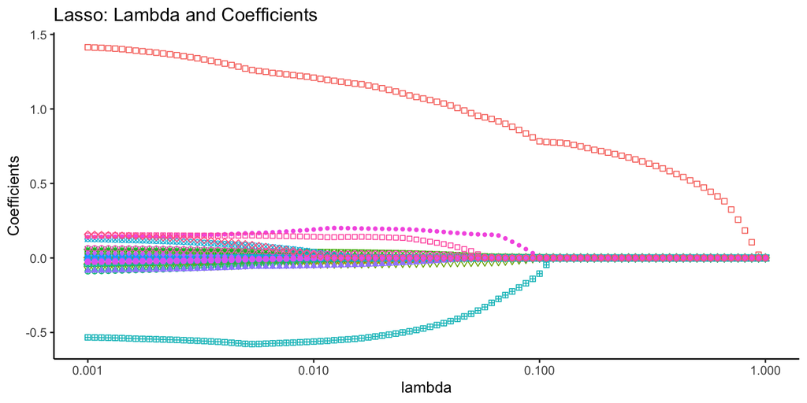

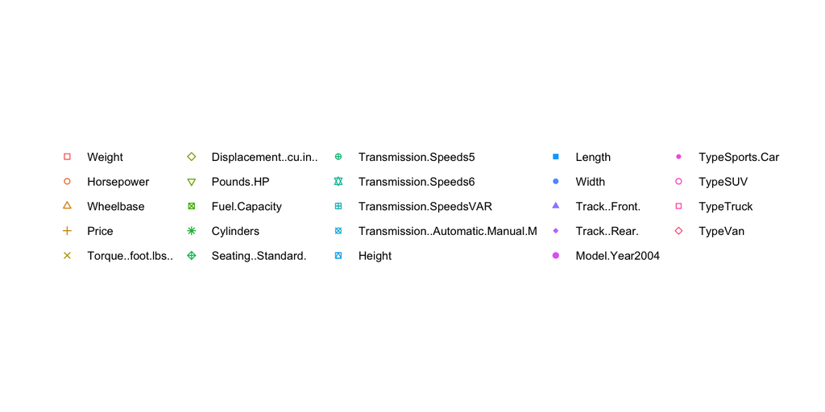

The plot records the LASSO estimator of each variable as $\lambda$ changes.

It seems that `Weight` survives until the end as $\lambda$ increases.

We could also check the situation when $\lambda$ is small

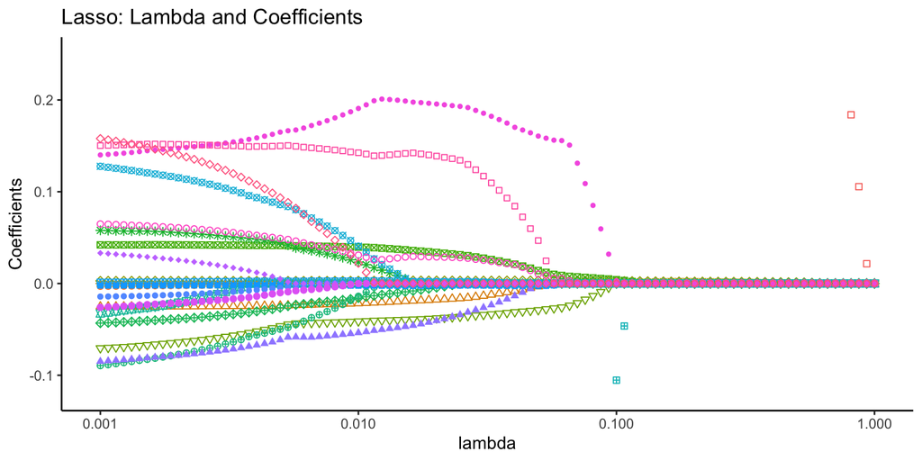

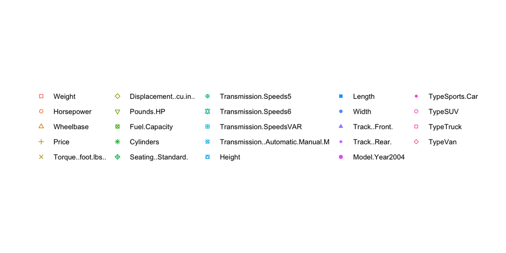

#### Cross Validation to select a $\lambda$

**The question becomes what is the optimal $\lambda$ to use.**

Cross-validation over $\lambda$ gives us a set of errors: Mean CV Error,`cvm`, CV standard deviation `cvsd`, CV Lower `cvlo` and CV Upper `cvup`.

To accomplish the Cross Validation, we use the function `cv.glmnet()`. Once again read through the code below and run it line by line.

```r
set.seed(10) # Set seed to guarantee the result is reproducible
fit.lasso.cv <- cv.glmnet(X.car, Y.car, alpha=1, nfolds=10,
                        lambda = 10^seq(-3,0,length=100))
```

```r
fit.lasso.cv$cvm               # the mean cv error for each lambda
```

```
##   [1] 1.1414528 1.1152542 1.0132608 0.9122028 0.8243328 0.7478455 0.6789727
##   [8] 0.6164440 0.5615682 0.5139300 0.4725859 0.4366151 0.4051472 0.3773628
##  [15] 0.3531238 0.3320517 0.3137447 0.2978288 0.2840080 0.2719920 0.2615659
##  [22] 0.2524981 0.2446423 0.2379692 0.2322577 0.2272145 0.2230131 0.2192978
##  [29] 0.2159665 0.2129197 0.2101119 0.2076514 0.2054266 0.2031591 0.2006678
##  [36] 0.1981697 0.1955383 0.1930869 0.1907118 0.1883876 0.1852387 0.1819965
##  [43] 0.1779990 0.1735472 0.1690816 0.1640563 0.1594886 0.1549784 0.1505564
##  [50] 0.1464639 0.1430593 0.1407082 0.1384838 0.1365916 0.1348403 0.1333090
##  [57] 0.1319628 0.1308452 0.1299774 0.1286225 0.1275790 0.1268494 0.1263563
##  [64] 0.1260537 0.1259382 0.1259553 0.1260349 0.1261511 0.1262959 0.1266042
##  [71] 0.1269619 0.1273185 0.1278648 0.1283800 0.1290284 0.1296543 0.1300395
##  [78] 0.1300856 0.1301980 0.1300996 0.1301563 0.1302332 0.1303252 0.1306248
##  [85] 0.1309468 0.1313670 0.1316994 0.1320672 0.1324343 0.1328330 0.1331384
##  [92] 0.1333478 0.1334862 0.1336353 0.1337500 0.1338703 0.1340133 0.1341366
##  [99] 0.1342785 0.1344100
```

```r
fit.lasso.cv$lambda.min        # lambda.min returns the min point amoth all the cvm.
```

```
## [1] 0.01149757
```

```r
fit.lasso.cv$nzero             # number of non-zero coeff's returned for each lambda
```

```
##  s0  s1  s2  s3  s4  s5  s6  s7  s8  s9 s10 s11 s12 s13 s14 s15 s16 s17 s18 s19
##   0   1   1   1   1   1   2   2   2   2   3   3   3   3   3   3   3   3   3   3
## s20 s21 s22 s23 s24 s25 s26 s27 s28 s29 s30 s31 s32 s33 s34 s35 s36 s37 s38 s39
##   3   3   3   3   3   3   4   4   4   4   5   5   6   7   8   8   8   8   8   8
## s40 s41 s42 s43 s44 s45 s46 s47 s48 s49 s50 s51 s52 s53 s54 s55 s56 s57 s58 s59
##   9   8  10  11  11  11  12  12  12  12  12  12  13  14  14  14  14  14  14  16
## s60 s61 s62 s63 s64 s65 s66 s67 s68 s69 s70 s71 s72 s73 s74 s75 s76 s77 s78 s79
##  16  16  16  16  18  18  18  19  19  19  19  19  20  20  20  22  22  22  22  22
## s80 s81 s82 s83 s84 s85 s86 s87 s88 s89 s90 s91 s92 s93 s94 s95 s96 s97 s98 s99
##  23  23  23  23  23  23  23  23  23  23  23  24  24  24  24  24  24  24  24  24
```

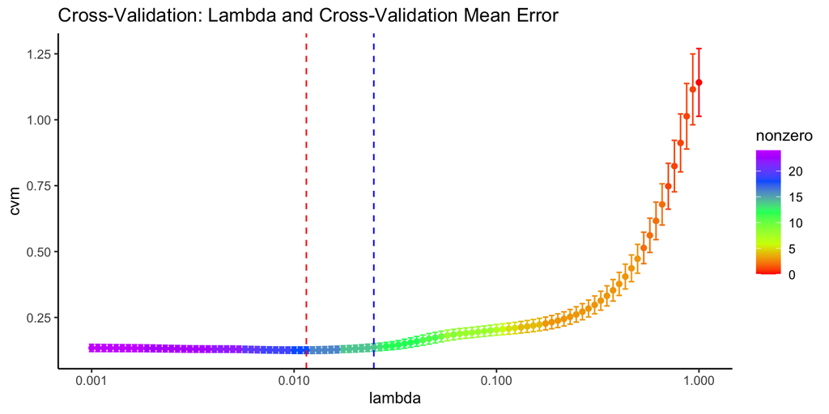

```r
df.lasso.cv <- data.frame(lambda = fit.lasso.cv$lambda,
                          cvm = fit.lasso.cv$cvm, nonzero = fit.lasso.cv$nzero)
df.lasso.cv$uci <- df.lasso.cv$cvm + fit.lasso.cv$cvsd
df.lasso.cv$lci <- df.lasso.cv$cvm - fit.lasso.cv$cvsd
ggplot(df.lasso.cv, aes(x = lambda, y = cvm, color = nonzero)) +
  geom_point() +
  scale_x_log10() +
  scale_color_gradientn(colours = rainbow(5)) +
  geom_errorbar(aes(ymin = lci, ymax= uci)) +
  geom_vline(xintercept = fit.lasso.cv$lambda.min, linetype="dashed", col = "red") +
  geom_vline(xintercept = fit.lasso.cv$lambda.1se, linetype="dashed", col = "blue") +
  ggtitle("Cross-Validation: Lambda and Cross-Validation Mean Error") +
  theme_classic()
```

We can also look at the number of non-zero coefficients. From this plot we show that as $\lambda \rightarrow \infty$, the impact of the shrinkage penalty grows, and the coefficient estimates will approach zero. Here, when $\lambda \approx 1$, all $\hat\beta$ are 0. When $\lambda \approx$ 0.0114976, they are 18 $\hat\beta$ that are non-zero.

**Remark:**

- We may choose any lambda between lambda.min and lambda.1se, the largest $\lambda$ whose cvm is within the cvsd bar for the lambda.min value.
- We may also choose lambda controlled by `nzero`, number of non-zero elements.

#### Output variables for the $\lambda$ chosen

Once a specific $\lambda$ is chosen we will output the corresponding predictors.

1. Output $\beta$’s from lambda.min, as an example

```r
coef.min <- coef(fit.lasso.cv, s="lambda.min")  #s=c("lambda.1se","lambda.min") or lambda value
coef.min <- coef.min[which(coef.min !=0),]   # get the non=zero coefficients
coef.min  # the set of predictors chosen
```

```
##                      (Intercept)                           Weight
##                     6.027549e+00                     1.195053e+00
##                        Wheelbase                            Price
##                    -2.087813e-02                    -2.100566e-06
##            Displacement..cu.in..                        Pounds.HP
##                     3.064634e-03                    -4.054415e-02
##                    Fuel.Capacity                        Cylinders
##                     3.906529e-02                     1.704422e-02
##               Seating..Standard.             Transmission.Speeds5
##                    -1.332079e-02                    -4.019147e-03
##           Transmission.SpeedsVAR Transmission..Automatic.Manual.M
##                    -5.561760e-01                     2.690744e-02
##                           Height                           Length
##                     2.820340e-03                    -2.346930e-03
##                    Track..Front.                   TypeSports.Car
##                    -5.126671e-02                     1.991617e-01
##                          TypeSUV                        TypeTruck
##                     2.574337e-02                     1.391108e-01
##                          TypeVan
##                     1.068359e-03
```

```r
#rownames(as.matrix(coef.min)) # shows only names, not estimates
#length(rownames(as.matrix(coef.min)))
```

2. output $\beta$’s from lambda.1se (this way you are using smaller set of variables.)

```r
coef.1se <- coef(fit.lasso.cv, s="lambda.1se")
coef.1se <- coef.1se[which(coef.1se !=0),]
coef.1se
```

```
##            (Intercept)                 Weight              Wheelbase
##           4.860912e+00           1.104486e+00          -1.613106e-02
##                  Price  Displacement..cu.in..              Pounds.HP
##          -3.214489e-07           3.158379e-03          -3.620922e-02
##          Fuel.Capacity     Seating..Standard. Transmission.SpeedsVAR
##           3.125679e-02          -2.314608e-04          -4.998267e-01
##                 Height                 Length          Track..Front.
##           1.773708e-03          -2.190397e-03          -3.407287e-02
##         TypeSports.Car                TypeSUV              TypeTruck
##           1.930125e-01           2.817758e-02           1.343024e-01
```

```r
#rownames(as.matrix(coef.1se))
```

3. Choose the number of non-zero coefficients

```r
coef.nzero <- coef(fit.lasso.cv, s = fit.lasso.cv$lambda[fit.lasso.cv$nzero==5])[,1]
coef.nzero <- coef.nzero[which(coef.nzero !=0)]
coef.nzero
```

```
##           (Intercept)                Weight            Horsepower
##          1.4652625587          0.7734187968          0.0010006579
##    Torque..foot.lbs.. Displacement..cu.in..         Fuel.Capacity
##          0.0013638536          0.0025042298          0.0008009782
```

```r
#rownames(as.matrix(coef.nzero)) #notice nzero may not take any integer.
```

### Final Model

#### Use variables chosen by LASSO

Use the variables chosen from the LASSO output and use `lm()` to give us the second stage linear model.

As an example, suppose we want to use the model whose $\lambda$ value is lambda.min. We will go through the next chunk to output the final linear model.

```r
coef.min <- coef(fit.lasso.cv, s="lambda.min")  #s=c("lambda.1se","lambda.min") or lambda value
coef.min <- coef.min[which(coef.min !=0),]   # get the non-zero coefficients
var.min <- rownames(as.matrix(coef.min)) # output the names
lm.input <- as.formula(paste("GPHM", "~", paste(var.min[-1], collapse = "+"))) # prepare for lm fomulae
lm.input
```

```
## GPHM ~ Weight + Wheelbase + Price + Displacement..cu.in.. + Pounds.HP +
##     Fuel.Capacity + Cylinders + Seating..Standard. + Transmission.Speeds5 +
##     Transmission.SpeedsVAR + Transmission..Automatic.Manual.M +
##     Height + Length + Track..Front. + TypeSports.Car + TypeSUV +
##     TypeTruck + TypeVan
```

Finally we fit the linear model with LASSO output variables.

```r
fit.min.lm <- lm(lm.input, data=matrix.car)
lm.output <- coef(fit.min.lm) # output lm estimates
summary(fit.min.lm)
```

```
##
## Call:
## lm(formula = lm.input, data = matrix.car)
##
## Residuals:
##      Min       1Q   Median       3Q      Max
## -0.92894 -0.20613 -0.00027  0.18671  1.23335
##
## Coefficients:
##                                    Estimate Std. Error t value Pr(>|t|)
## (Intercept)                       7.337e+00  9.841e-01   7.456 2.86e-12 ***
## Weight                            1.307e+00  9.906e-02  13.191  < 2e-16 ***
## Wheelbase                        -2.633e-02  8.168e-03  -3.223  0.00149 **
## Price                            -3.798e-06  1.274e-06  -2.981  0.00324 **
## Displacement..cu.in..             2.484e-03  1.222e-03   2.032  0.04353 *
## Pounds.HP                        -4.617e-02  8.639e-03  -5.345 2.52e-07 ***
## Fuel.Capacity                     4.339e-02  1.402e-02   3.096  0.00225 **
## Cylinders                         5.993e-02  4.720e-02   1.270  0.20573
## Seating..Standard.               -3.231e-02  2.903e-02  -1.113  0.26706
## Transmission.Speeds5             -7.732e-02  5.712e-02  -1.354  0.17740
## Transmission.SpeedsVAR           -5.918e-01  1.959e-01  -3.021  0.00285 **
## Transmission..Automatic.Manual.M  1.312e-01  7.330e-02   1.789  0.07510 .
## Height                            2.132e-03  6.780e-03   0.314  0.75355
## Length                           -2.153e-03  4.748e-03  -0.454  0.65068
## Track..Front.                    -6.919e-02  1.560e-02  -4.435 1.54e-05 ***
## TypeSports.Car                    1.357e-01  1.070e-01   1.268  0.20636
## TypeSUV                           6.333e-02  8.496e-02   0.745  0.45690
## TypeTruck                         1.626e-01  1.280e-01   1.270  0.20559
## TypeVan                           1.589e-01  1.207e-01   1.316  0.18961
## ---
## Signif. codes:  0 '***' 0.001 '**' 0.01 '*' 0.05 '.' 0.1 ' ' 1
##
## Residual standard error: 0.3176 on 195 degrees of freedom
## Multiple R-squared:  0.9191, Adjusted R-squared:  0.9116
## F-statistic:   123 on 18 and 195 DF,  p-value: < 2.2e-16
```

**Remark:**

- Not all the predictors in the above lm() are significant at .05 level. We will go one more step further to eliminate some insignificant predictors.
- The LASSO estimates are different from that from lm which is shown below:

```r
comp <- data.frame(coef.min, lm.output)
names(comp) <- c("estimates from LASSO", "lm estimates")
comp
```

```
##                                  estimates from LASSO  lm estimates
## (Intercept)                              6.027549e+00  7.336874e+00
## Weight                                   1.195053e+00  1.306727e+00
## Wheelbase                               -2.087813e-02 -2.632574e-02
## Price                                   -2.100566e-06 -3.797878e-06
## Displacement..cu.in..                    3.064634e-03  2.483756e-03
## Pounds.HP                               -4.054415e-02 -4.617375e-02
## Fuel.Capacity                            3.906529e-02  4.339407e-02
## Cylinders                                1.704422e-02  5.992901e-02
## Seating..Standard.                      -1.332079e-02 -3.231491e-02
## Transmission.Speeds5                    -4.019147e-03 -7.732033e-02
## Transmission.SpeedsVAR                  -5.561760e-01 -5.918161e-01
## Transmission..Automatic.Manual.M         2.690744e-02  1.311577e-01
## Height                                   2.820340e-03  2.131740e-03
## Length                                  -2.346930e-03 -2.153249e-03
## Track..Front.                           -5.126671e-02 -6.918807e-02
## TypeSports.Car                           1.991617e-01  1.356640e-01
## TypeSUV                                  2.574337e-02  6.333472e-02
## TypeTruck                                1.391108e-01  1.625867e-01
## TypeVan                                  1.068359e-03  1.589119e-01
```

Still some variables are not significant. We still need to tune the model and end up with one that you think is acceptable!!!!!!

#### Model Selection

We create a function that takes an input from a data frame of the `regsubsets` output.

This function outputs A final model which achieves the following:

- All subset selection results
- Report the largest p-values with each model
- Return the final model who’s largest $p$-value < $\alpha$

```r
fit.exh <- regsubsets(lm.input, nvmax= length(var.min)-1, method="exhau",  matrix.car)
f.e <- summary(fit.exh)
```

```r
coef(fit.exh, which.min(f.e$bic))
```

```
##            (Intercept)                 Weight              Wheelbase
##           7.867636e+00           1.296181e+00          -2.930793e-02
##                  Price  Displacement..cu.in..              Pounds.HP
##          -3.338914e-06           3.400609e-03          -4.183438e-02
##          Fuel.Capacity Transmission.SpeedsVAR          Track..Front.
##           5.078524e-02          -6.276848e-01          -7.970635e-02
##         TypeSports.Car
##           2.446103e-01
```

#### Final Model

```r
var.exh <- names(coef(fit.exh, which.min(f.e$bic)))
lm.final <- as.formula(paste("GPHM", "~", paste(var.exh[-1], collapse = "+")))
lm.final
```

```
## GPHM ~ Weight + Wheelbase + Price + Displacement..cu.in.. + Pounds.HP +
##     Fuel.Capacity + Transmission.SpeedsVAR + Track..Front. +
##     TypeSports.Car
```

```r
fit.final <- lm(lm.final, data=matrix.car)
summary(fit.final)
```

```
##
## Call:
## lm(formula = lm.final, data = matrix.car)
##
## Residuals:
##      Min       1Q   Median       3Q      Max
## -0.88752 -0.19677 -0.01199  0.18137  1.44717
##
## Coefficients:
##                          Estimate Std. Error t value Pr(>|t|)
## (Intercept)             7.868e+00  7.473e-01  10.527  < 2e-16 ***
## Weight                  1.296e+00  8.344e-02  15.534  < 2e-16 ***
## Wheelbase              -2.931e-02  4.896e-03  -5.986 9.55e-09 ***
## Price                  -3.339e-06  1.119e-06  -2.985 0.003185 **
## Displacement..cu.in..   3.401e-03  7.919e-04   4.294 2.71e-05 ***
## Pounds.HP              -4.183e-02  7.731e-03  -5.411 1.75e-07 ***
## Fuel.Capacity           5.079e-02  1.321e-02   3.846 0.000161 ***
## Transmission.SpeedsVAR -6.277e-01  1.893e-01  -3.316 0.001082 **
## Track..Front.          -7.971e-02  1.415e-02  -5.632 5.85e-08 ***
## TypeSports.Car          2.446e-01  8.990e-02   2.721 0.007074 **
## ---
## Signif. codes:  0 '***' 0.001 '**' 0.01 '*' 0.05 '.' 0.1 ' ' 1
##
## Residual standard error: 0.3195 on 204 degrees of freedom
## Multiple R-squared:  0.9143, Adjusted R-squared:  0.9105
## F-statistic: 241.9 on 9 and 204 DF,  p-value: < 2.2e-16
```

## 3. Other Regularization Methods

### Ridge Regression - $L_2$ norm

Once again, glmnet will be used. Ridge Regression is implemented similarly to LASSO. We just need to set $\alpha$ as 0.

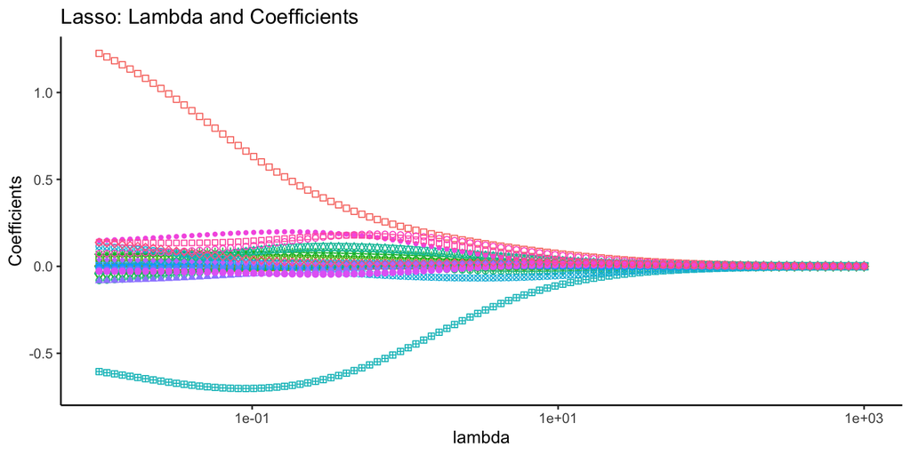

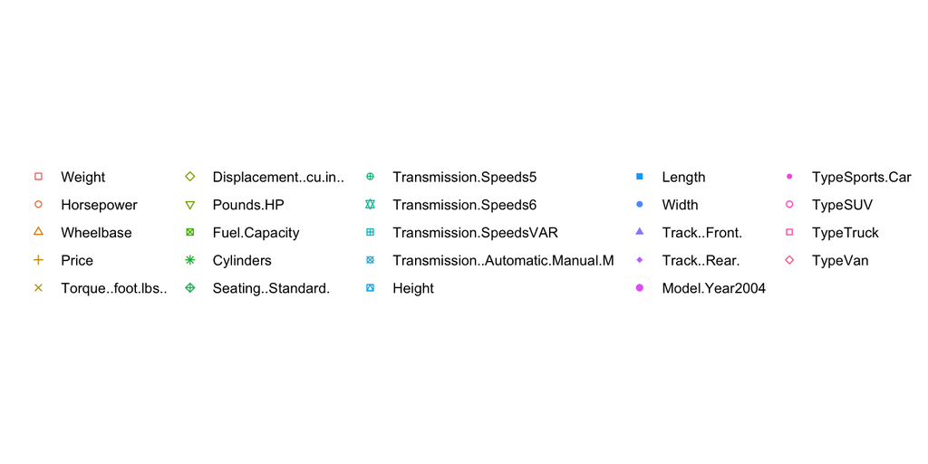

```r
fit.car.ridge <- glmnet(X.car, Y.car, alpha=0,
                        lambda = 10^seq(-2,3,length=100))
#plot(fit.car.ridge)
```

We tune $\lambda$ via Cross-Validation.

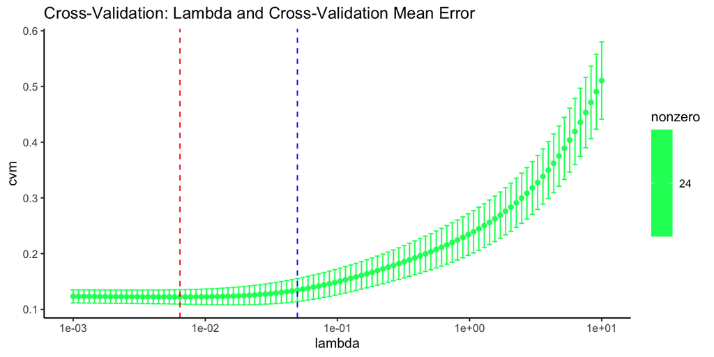

```r
fit.ridge.cv <- cv.glmnet(X.car, Y.car, alpha=0, nfolds=10,
                        lambda = 10^seq(-3,1,length=100))
#plot(fit.ridge.cv)
```

Oops, is something wrong? All the features are returned!

**Remark:**

- Ridge regression doesn’t cut any variable
- The solutions are unique though

### Elastic Net (More advanced)

Elastic Net combines Ridge Regression and LASSO, by choosing $\alpha \ne 1,0$. An $\alpha$ near 0 will put more emphasis towards Ridge Regression. For us, we want $\alpha$ close to 1 so that it will do feature selection, yet still benefit from Ridge Regression.

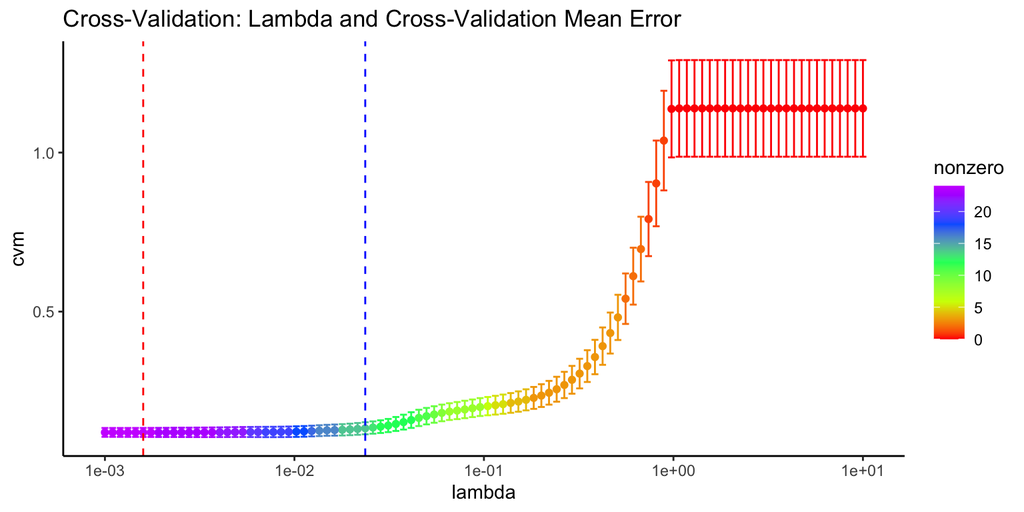

```r
fit.car.lambda <- glmnet(X.car, Y.car, alpha=.99,
                         lambda = 10^seq(-3,1,length=100))
fit.enet.cv <- cv.glmnet(X.car, Y.car, alpha=.99, nfolds=10,
                         lambda = 10^seq(-3,1,length=100))
#plot(fit.enet.cv)
```

### Regularization in General (For Additional Reading)

LASSO uses $L_1$ penalty and Ridge uses $L_2$ penalty. In general we may choose the following penalty functions:

$$\frac{1-\alpha}{2}||\beta||_2^2 + \alpha
||\beta||_1.$$

- Here $||\beta||_2^2$ is called the $L_2$ Norm and $||\beta||_1$ is called the $L_1$ Norm.

We now take this penalty term and add it to our original minimization problem, which just minimizes the sum of squared error. Therefore, our new minimization function becomes:

$$\text{minimize } \frac{RSS}{2n} +
\lambda \left( \frac{1-\alpha}{2}||\beta||_2^2 + \alpha ||\beta||_1
\right).$$

**Remark:**

- $0 \leq \alpha \leq 1$ is another tuning parameter as well as $\lambda$
- LASSO: When $\alpha=1$
- Ridge: When $\alpha=0$
- Elastic Net for any $\alpha$

**Note:** When $\lambda = 0$, the penalty term has no effect, and will produce the least squares estimates. However, as $\lambda \rightarrow \infty$, the impact of the shrinkage penalty grows, and the coefficient estimates will approach zero.

## 4. Appendix

### Appendix I: `lm()` vs. `glmnet(lambda=0)`

`glmnet` should output OLS estimates when lambda=0

```r
X.car.0 <- model.matrix(GPHM ~ Weight + Horsepower, data.car)[, -1]
```

Next, a fit when $\lambda = 0$:

```r
fit.lasso.0 <- glmnet(X.car.0,Y.car, alpha=1, lambda=0)    # glmnet when lambda=0
coef(fit.lasso.0)
```

```
## 3 x 1 sparse Matrix of class "dgCMatrix"
##                      s0
## (Intercept) 0.660081424
## Weight      1.014607247
## Horsepower  0.004576906
```

As a check, we fit a linear model using the same predictors as above. This gives us the OLS estimates.

```r
fit.lm <- lm(GPHM ~ Weight + Horsepower, data.car)
coef(fit.lm)
```

```
## (Intercept)      Weight  Horsepower
## 0.660263867 1.014518243 0.004577571
```

### Appendix II - More On Cross Validation

Which lambda to use?????? We use k fold cross validation. Let’s explore the effect of $\lambda$. We may use `cv.glmnet()` to find the best $\lambda$. `cv.glmnet()` outputs the nfolds of errors for each lambda.

By default `nfolds=10`, the smallest value can be 3 and the largest can be $n$, i.e. leave-one-out-Cross-Validation (LOOCV).

By default `type.measure = "deviance"` which is $MSE$ in our case.

- type.measure=“class” will be classification error
- type.measure can also be “auc”, “mse”

`cv.glmnet` will choose a set of $\lambda$’s to use.

### Appendix III - K-Fold Cross Validation

The simplest way to estimate prediction errors with a training set is called K-Fold Cross Validation. To compute K-fold cross validation error, we use the following algorithm.

In more mathematical terms:

Divide our data set at **random** into $K$ sets of equal size, $S_1,\dots,S_K$. Each set is called a fold.

Now For $k = 1, \dots, K$ we do the following:

1. Train our model using the following training set:
   $$\mathcal{D}_k = \bigcup_{j\ne k} S_j.$$
   **Note that $\mathcal{D}_k$ contains all folds *except* the $k$’th fold.**
2. Compute Mean Squared Error on the $k$’th fold, i.e. the fold that was not used to train our model:

$$MSE_k = \frac{1}{n}\sum_{(x_{ip}) \in
S_k}^n (y_i - \hat\beta_0 - \hat\beta_1 x_{i1} - \ldots - \hat\beta_p
x_{ip})^{2}.$$
3. After doing this for each fold, The cross validation error is the average error across all folds:
$$error = \frac{1}{K} \sum_{k=1}^K
MSE_k.$$